© Bản quyền thuộc về Quantopian Inc.  
© Bản quyền sửa đổi thuộc về AI Cafe¹  
Giấy phép [Creative Commons Attribution 4.0](https://creativecommons.org/licenses/by/4.0/legalcode).  
[Khuyến cáo](https://aicafe.one/khuyen-cao/)

# Những khuyết tật của các mô hình hồi quy

By Evgenia "Jenny" Nitishinskaya and Delaney Mackenzie

Edited by AI Cafe¹

Khi sử dụng hồi quy để phù hợp với mô hình dữ liệu của chúng ta, các giả định của phân tích hồi quy phải được thỏa mãn để đảm bảo ước lượng tham số tốt và thống kê phù hợp chính xác. Chúng ta mong muốn các tham số phải:

- không thiên lệch (giá trị kỳ vọng qua nhiều mẫu là giá trị thực)
- nhất quán (tiến gần đến giá trị thực với nhiều mẫu), và
- hiệu quả (biến thiên được tối thiểu hóa)

Dưới đây, chúng ta sẽ điều tra cách mà những giả định này có thể bị vi phạm và ảnh hưởng của chúng đến các tham số và thống kê phù hợp. Chúng ta sẽ sử dụng các phương trình hồi quy tuyến tính một biến cho các ví dụ, nhưng những xem xét tương tự cũng áp dụng cho các mô hình khác. Chúng ta cũng sẽ giả định rằng mô hình của chúng ta được xác định đúng; tức là, hình thức chức năng mà chúng ta chọn là hợp lệ. Chúng ta sẽ thảo luận về các lỗi xác định mô hình cùng với các vi phạm giả định và các vấn đề khác mà chúng gây ra trong một bài giảng khác.

## Tập trung vào các phần dư (residuals)

Thay vì tập trung vào việc xây dựng mô hình, bạn có thể thu thập được một lượng thông tin lớn từ các phần dư (lỗi) của mình. Mô hình của bạn có thể rất phức tạp và khó phân tích, nhưng miễn là bạn có các dự đoán và giá trị quan sát, bạn có thể tính toán được các phần dư. Khi bạn có các phần dư, bạn có thể thực hiện nhiều bài kiểm tra thống kê.

Nếu các phần dư của bạn không tuân theo một phân phối nhất định (thường là phân phối chuẩn, nhưng phụ thuộc vào mô hình của bạn), thì bạn biết rằng có điều gì đó không ổn và bạn nên quan tâm đến độ chính xác của các dự đoán của mình.

## Phần dư không phân phối chuẩn

Nếu thành phần lỗi không phải là phân phối chuẩn, thì các kiểm định về ý nghĩa thống kê của chúng ta sẽ không chính xác. May mắn thay, định lý giới hạn trung tâm cho chúng ta biết rằng, đối với các mẫu dữ liệu đủ lớn, các phân phối hệ số sẽ gần như là phân phối chuẩn ngay cả khi các lỗi không phải như vậy. Do đó, phân tích của chúng ta vẫn sẽ hợp lệ cho các tập dữ liệu lớn.

## Kiểm tra tính chuẩn

Một bài kiểm tra tốt cho tính chuẩn là bài kiểm tra Jarque-Bera. Nó có một triển khai bằng python tại `statsmodels.stats.stattools.jarque_bera`, và chúng ta sẽ sử dụng nó thường xuyên trong tài liệu này.

Hãy luôn kiểm tra tính chuẩn!

Nó cực kỳ dễ dàng và có thể giúp bạn tiết kiệm rất nhiều thời gian.

```python
# Import all the libraries we'll be using
import numpy as np
import statsmodels.api as sm
from statsmodels import regression, stats
import statsmodels
import matplotlib.pyplot as plt
```

```python
residuals = np.random.normal(0, 1, 100)

_, pvalue, _, _ = statsmodels.stats.stattools.jarque_bera(residuals)
print(pvalue)

residuals = np.random.poisson(size=100)

_, pvalue, _, _ = statsmodels.stats.stattools.jarque_bera(residuals)
print(pvalue)
```

```
0.5245579471415447
6.6636967136092214e-12
```

## Tính không đồng nhất phương sai (Heteroskedasticity)

Tính không đồng nhất phương sai có nghĩa là phương sai của các sai số không đồng nhất giữa các quan sát. Một cách trực giác, điều này có nghĩa là các quan sát không phân phối đồng nhất dọc theo đường hồi quy. Nó thường xảy ra trong dữ liệu cắt ngang, nơi mà sự khác biệt trong các mẫu mà chúng ta đang đo lường dẫn đến sự khác biệt về phương sai.

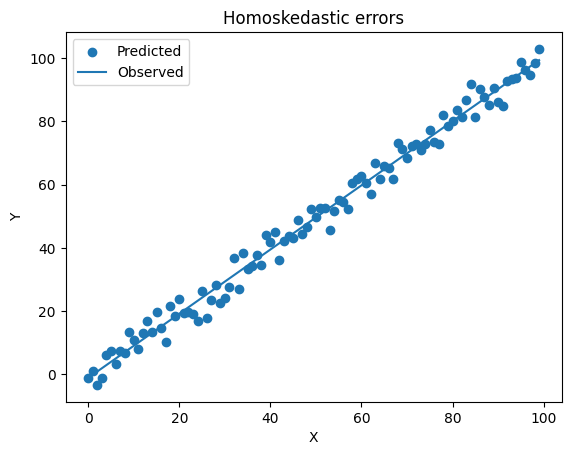

```python
# Artificially create dataset with constant variance around a line
xs = np.arange(100)
y1 = xs + 3*np.random.randn(100)

# Get results of linear regression
slr1 = regression.linear_model.OLS(y1, sm.add_constant(xs)).fit()

# Construct the fit line
fit1 = slr1.params[0] + slr1.params[1]*xs

# Plot data and regression line
plt.scatter(xs, y1)
plt.plot(xs, fit1)
plt.title('Homoskedastic errors');
plt.legend(['Predicted', 'Observed'])
plt.xlabel('X')
plt.ylabel('Y');
```

OLS Regression Results

| Dep. Variable: | y | R-squared: | 0.452 |
| --- | --- | --- | --- |
| Model: | OLS | Adj. R-squared: | 0.446 |
| Method: | Least Squares | F-statistic: | 80.73 |
| Date: | Fri, 18 Apr 2025 | Prob (F-statistic): | 1.93e-14 |
| Time: | 03:56:04 | Log-Likelihood: | -477.53 |
| No. Observations: | 100 | AIC: | 959.1 |
| Df Residuals: | 98 | BIC: | 964.3 |
| Df Model: | 1 |  |  |
| Covariance Type: | nonrobust |  |  |

|  | coef | std err | t | P>\|t\| | [0.025 | 0.975] |
| --- | --- | --- | --- | --- | --- | --- |
| const | 4.4285 | 5.752 | 0.770 | 0.443 | -6.986 | 15.843 |
| x1 | 0.9019 | 0.100 | 8.985 | 0.000 | 0.703 | 1.101 |

| Omnibus: | 11.573 | Durbin-Watson: | 1.846 |
| --- | --- | --- | --- |
| Prob(Omnibus): | 0.003 | Jarque-Bera (JB): | 27.021 |
| Skew: | 0.286 | Prob(JB): | 1.36e-06 |
| Kurtosis: | 5.482 | Cond. No. | 114. |

Notes:  
[1] Standard Errors assume that the covariance matrix of the errors is correctly specified.

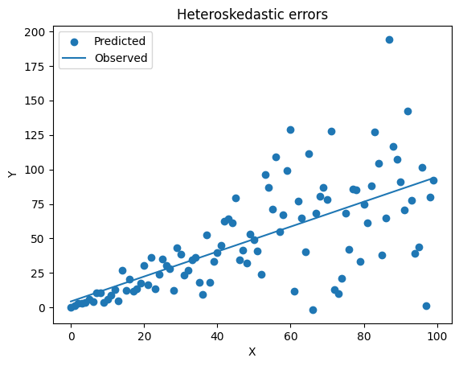

```python
# Artificially create dataset with changing variance around a line
y2 = xs*(1 + .5*np.random.randn(100))

# Perform linear regression
slr2 = regression.linear_model.OLS(y2, sm.add_constant(xs)).fit()
fit2 = slr2.params[0] + slr2.params[1]*xs

# Plot data and regression line
plt.scatter(xs, y2)
plt.plot(xs, fit2)
plt.title('Heteroskedastic errors')
plt.legend(['Predicted', 'Observed'])
plt.xlabel('X')
plt.ylabel('Y')

# Print summary of regression results
slr2.summary()
```

### Kiểm tra Heteroskedasticity

Bạn có thể kiểm tra heteroskedasticity bằng một vài bài kiểm tra, chúng ta sẽ sử dụng bài kiểm tra Breush Pagan từ thư viện statsmodels. Chúng ta cũng sẽ kiểm tra tính chuẩn, điều này trong trường hợp này cũng sẽ phát hiện ra sự kỳ lạ trong trường hợp thứ hai. Mặc dù vậy, có thể có các phần dư được phân phối chuẩn mà cũng có tính heteroskedastic, vì vậy cả hai bài kiểm tra đều phải được thực hiện để đảm bảo.

```python
residuals1 = y1-fit1
residuals2 = y2-fit2

xs_with_constant = sm.add_constant(xs)

_, jb_pvalue1, _, _ = statsmodels.stats.stattools.jarque_bera(residuals1)
_, jb_pvalue2, _, _ = statsmodels.stats.stattools.jarque_bera(residuals2)
print("p-value for residuals1 being normal", jb_pvalue1)
print("p-value for residuals2 being normal", jb_pvalue2)

_, pvalue1, _, _ = stats.diagnostic.het_breuschpagan(residuals1, xs_with_constant)
_, pvalue2, _, _ = stats.diagnostic.het_breuschpagan(residuals2, xs_with_constant)
print("p-value for residuals1 being heteroskedastic", pvalue1)
print("p-value for residuals2 being heteroskedastic", pvalue2)
```

```
p-value for residuals1 being normal 0.39606227354985907
p-value for residuals2 being normal 1.35631073863894e-06
p-value for residuals1 being heteroskedastic 0.3559188293949256
p-value for residuals2 being heteroskedastic 5.8057737332290035e-05
```

Heteroskedasticity ảnh hưởng đến phân tích của chúng ta như thế nào? Tình huống vấn đề, được gọi là heteroskedasticity điều kiện, là khi phương sai lỗi có mối tương quan với các biến độc lập như đã nêu ở trên. Điều này làm cho bài kiểm tra F để xác định ý nghĩa của hồi quy và các bài kiểm tra t cho ý nghĩa của các hệ số riêng lẻ trở nên không đáng tin cậy. Thường thì điều này dẫn đến việc ước lượng quá mức ý nghĩa của sự phù hợp.

Kiểm tra Breusch-Pagan và kiểm tra White có thể được sử dụng để phát hiện heteroskedasticity điều kiện. Nếu chúng ta nghi ngờ rằng hiệu ứng này tồn tại, chúng ta có thể điều chỉnh mô hình của mình để cố gắng sửa chữa cho nó. Một phương pháp là bình phương tối thiểu tổng quát, yêu cầu một sự thay đổi thủ công của phương trình gốc. Một phương pháp khác là tính toán sai số chuẩn mạnh mẽ, điều chỉnh các thống kê phù hợp để tính đến heteroskedasticity. `statsmodels` có thể tính toán sai số chuẩn mạnh mẽ; lưu ý sự khác biệt trong các thống kê bên dưới.

```python
print(slr2.summary())
print(slr2.get_robustcov_results().summary())
```

```
                            OLS Regression Results
==============================================================================
Dep. Variable:                      y   R-squared:                       0.452
Model:                            OLS   Adj. R-squared:                  0.446
Method:                 Least Squares   F-statistic:                     80.73
Date:                Fri, 18 Apr 2025   Prob (F-statistic):           1.93e-14
Time:                        03:56:04   Log-Likelihood:                -477.53
No. Observations:                 100   AIC:                             959.1
Df Residuals:                      98   BIC:                             964.3
Df Model:                           1
Covariance Type:            nonrobust
==============================================================================
                 coef    std err          t      P>|t|      [0.025      0.975]
------------------------------------------------------------------------------
const          4.4285      5.752      0.770      0.443      -6.986      15.843
x1             0.9019      0.100      8.985      0.000       0.703       1.101
==============================================================================
Omnibus:                       11.573   Durbin-Watson:                   1.846
Prob(Omnibus):                  0.003   Jarque-Bera (JB):               27.021
Skew:                           0.286   Prob(JB):                     1.36e-06
Kurtosis:                       5.482   Cond. No.                         114.
==============================================================================

Notes:
[1] Standard Errors assume that the covariance matrix of the errors is correctly specified.
                            OLS Regression Results
==============================================================================
Dep. Variable:                      y   R-squared:                       0.452
Model:                            OLS   Adj. R-squared:                  0.446
Method:                 Least Squares   F-statistic:                     73.40
Date:                Fri, 18 Apr 2025   Prob (F-statistic):           1.54e-13
Time:                        03:56:04   Log-Likelihood:                -477.53
No. Observations:                 100   AIC:                             959.1
Df Residuals:                      98   BIC:                             964.3
Df Model:                           1
Covariance Type:                  HC1
==============================================================================
                 coef    std err          t      P>|t|      [0.025      0.975]
------------------------------------------------------------------------------
const          4.4285      3.323      1.333      0.186      -2.165      11.022
x1             0.9019      0.105      8.568      0.000       0.693       1.111
==============================================================================
Omnibus:                       11.573   Durbin-Watson:                   1.846
Prob(Omnibus):                  0.003   Jarque-Bera (JB):               27.021
Skew:                           0.286   Prob(JB):                     1.36e-06
Kurtosis:                       5.482   Cond. No.                         114.
==============================================================================

Notes:
[1] Standard Errors are heteroscedasticity robust (HC1)
```

## Tương quan chuỗi của lỗi

Một vấn đề phổ biến và nghiêm trọng là khi các lỗi có tương quan giữa các quan sát (được gọi là tương quan chuỗi hoặc tự tương quan). Điều này có thể xảy ra, chẳng hạn, khi một số điểm dữ liệu có liên quan hoặc khi chúng ta sử dụng dữ liệu chuỗi thời gian với những biến động theo chu kỳ. Nếu một trong các biến độc lập phụ thuộc vào các giá trị trước đó của biến phụ thuộc - chẳng hạn như khi nó bằng giá trị của biến phụ thuộc trong kỳ trước - hoặc nếu việc chỉ định mô hình sai dẫn đến tự tương quan, thì các ước lượng hệ số sẽ không nhất quán và do đó không hợp lệ. Ngược lại, các ước lượng tham số sẽ hợp lệ, nhưng các thống kê độ phù hợp sẽ không chính xác. Ví dụ, nếu tương quan là dương, chúng ta sẽ có các thống kê F và t bị thổi phồng, dẫn đến việc chúng ta ước lượng quá cao về sự quan trọng của mô hình.

Nếu các lỗi là đồng phương sai, chúng ta có thể kiểm tra sự tự tương quan bằng cách sử dụng kiểm tra Durbin-Watson, điều này được báo cáo thuận tiện trong tóm tắt hồi quy trong `statsmodels`.

```python
# Cài thư viện lấy dữ liệu miễn phí
!curl -fsSLO https://raw.githubusercontent.com/algo-stocks/data/master/data.py
```

OLS Regression Results

| Dep. Variable: | FPT | R-squared: | 0.892 |
| --- | --- | --- | --- |
| Model: | OLS | Adj. R-squared: | 0.892 |
| Method: | Least Squares | F-statistic: | 2055. |
| Date: | Fri, 18 Apr 2025 | Prob (F-statistic): | 5.32e-122 |
| Time: | 03:56:21 | Log-Likelihood: | -829.30 |
| No. Observations: | 250 | AIC: | 1663. |
| Df Residuals: | 248 | BIC: | 1670. |
| Df Model: | 1 |  |  |
| Covariance Type: | nonrobust |  |  |

|  | coef | std err | t | P>\|t\| | [0.025 | 0.975] |
| --- | --- | --- | --- | --- | --- | --- |
| const | 85.7458 | 0.845 | 101.463 | 0.000 | 84.081 | 87.410 |
| x1 | 0.2662 | 0.006 | 45.327 | 0.000 | 0.255 | 0.278 |

| Omnibus: | 20.532 | Durbin-Watson: | 0.073 |
| --- | --- | --- | --- |
| Prob(Omnibus): | 0.000 | Jarque-Bera (JB): | 23.068 |
| Skew: | 0.712 | Prob(JB): | 9.79e-06 |
| Kurtosis: | 3.432 | Cond. No. | 287. |

Notes:  
[1] Standard Errors assume that the covariance matrix of the errors is correctly specified.

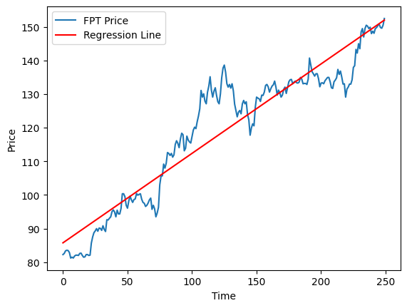

```python
from data import get_prices

start = '2024-01-01'
end = '2025-01-01'

prices = get_prices('FPT', start_date=start, end_date=end)

y = prices.FPT
x = np.arange(len(y))

# Regress pricing data against time
model = regression.linear_model.OLS(y, sm.add_constant(x)).fit()

# Construct the fit line
prediction = model.params.iloc[0] + model.params.iloc[1]*x

# Plot pricing data and regression line
plt.plot(x,y)
plt.plot(x, prediction, color='r')
plt.legend(['FPT Price', 'Regression Line'])
plt.xlabel('Time')
plt.ylabel('Price')

# Print summary of regression results
model.summary()
```

### Kiểm tra Tự tương quan

Chúng ta có thể kiểm tra sự tự tương quan trong cả giá cả và phần dư. Chúng ta sẽ sử dụng phương pháp tích hợp sẵn để làm điều này, dựa trên bài kiểm tra Ljun-Box. Bài kiểm tra này tính toán xác suất rằng dữ liệu điểm trễ n-th có thể dự đoán được giá trị hiện tại. Nếu không có độ trễ tối đa nào được cung cấp, thì hàm sẽ tính toán một độ trễ tối đa và trả về các giá trị p cho tất cả các độ trễ đến độ trễ đó. Chúng ta có thể thấy rằng với 5 điểm dữ liệu gần đây nhất, có một sự tương quan đáng kể với giá trị hiện tại. Do đó, chúng ta kết luận rằng cả dữ liệu đều có tính tự tương quan.

Chúng ta cũng kiểm tra tính chuẩn tắc cho vui.

```python
_, prices_qstats, prices_qstat_pvalues = statsmodels.tsa.stattools.acf(y, qstat=True, nlags=40, fft=False)
_, prices_qstats, prices_qstat_pvalues = statsmodels.tsa.stattools.acf(y - prediction, qstat=True, nlags=40, fft=False)

print('Prices autocorrelation p-values', prices_qstat_pvalues)
print('Residuals autocorrelation p-values', prices_qstat_pvalues)

_, jb_pvalue, _, _ = statsmodels.stats.stattools.jarque_bera(y - prediction)

print('Jarque-Bera p-value that residuals are normally distributed', jb_pvalue)
```

```
Prices autocorrelation p-values [5.93175757e-053 3.43777933e-098 1.42298033e-139 9.04734280e-178
 1.58738665e-213 2.16635786e-246 7.21980331e-277 6.27627077e-305
 0.00000000e+000 0.00000000e+000 0.00000000e+000 0.00000000e+000
 0.00000000e+000 0.00000000e+000 0.00000000e+000 0.00000000e+000
 0.00000000e+000 0.00000000e+000 0.00000000e+000 0.00000000e+000
 0.00000000e+000 0.00000000e+000 0.00000000e+000 0.00000000e+000
 0.00000000e+000 0.00000000e+000 0.00000000e+000 0.00000000e+000
 0.00000000e+000 0.00000000e+000 0.00000000e+000 0.00000000e+000
 0.00000000e+000 0.00000000e+000 0.00000000e+000 0.00000000e+000
 0.00000000e+000 0.00000000e+000 0.00000000e+000 0.00000000e+000]
Residuals autocorrelation p-values [5.93175757e-053 3.43777933e-098 1.42298033e-139 9.04734280e-178
 1.58738665e-213 2.16635786e-246 7.21980331e-277 6.27627077e-305
 0.00000000e+000 0.00000000e+000 0.00000000e+000 0.00000000e+000
 0.00000000e+000 0.00000000e+000 0.00000000e+000 0.00000000e+000
 0.00000000e+000 0.00000000e+000 0.00000000e+000 0.00000000e+000
 0.00000000e+000 0.00000000e+000 0.00000000e+000 0.00000000e+000
 0.00000000e+000 0.00000000e+000 0.00000000e+000 0.00000000e+000
 0.00000000e+000 0.00000000e+000 0.00000000e+000 0.00000000e+000
 0.00000000e+000 0.00000000e+000 0.00000000e+000 0.00000000e+000
 0.00000000e+000 0.00000000e+000 0.00000000e+000 0.00000000e+000]
Jarque-Bera p-value that residuals are normally distributed 9.791286217083527e-06
```

## Newey-West

Newey-West là một phương pháp tính toán phương sai mà tính đến sự tự tương quan. Một phép tính phương sai đơn giản sẽ thực sự tạo ra các sai số chuẩn không chính xác khi có sự tự tương quan.

Chúng ta có thể cố gắng thay đổi phương trình hồi quy để loại bỏ sự tương quan chuỗi. Một cách khắc phục đơn giản hơn là điều chỉnh các sai số chuẩn bằng cách sử dụng một phương pháp thích hợp và sử dụng các giá trị đã điều chỉnh để kiểm tra sự ý nghĩa. Dưới đây, chúng ta sử dụng phương pháp Newey-West từ `statsmodels` để tính toán các sai số chuẩn đã điều chỉnh cho các hệ số. Chúng cao hơn so với các giá trị ban đầu được báo cáo bởi hồi quy, điều này là điều chúng ta mong đợi đối với các sai số có tương quan dương.

```python
from math import sqrt

# Find the covariance matrix of the coefficients
cov_mat = stats.sandwich_covariance.cov_hac(model)

# Print the standard errors of each coefficient from the original model and from the adjustment
print('Old standard errors:', model.bse.iloc[0], model.bse.iloc[1])
print('Adjusted standard errors:', sqrt(cov_mat[0,0]), sqrt(cov_mat[1,1]))
```

```
Old standard errors: 0.8450974168339878 0.005872627480799045
Adjusted standard errors: 1.5855806799173218 0.010221575699845614
```

## Đa tương quan

Khi sử dụng nhiều biến độc lập, việc kiểm tra đa tương quan là rất quan trọng; tức là, một mối quan hệ tuyến tính gần đúng giữa các biến độc lập, chẳng hạn như $$ X_2 \approx 5 X_1 - X_3 + 4.5 $$

Với đa tương quan, việc xác định ảnh hưởng độc lập của từng biến là khó khăn, vì chúng ta có thể thay đổi các hệ số theo mối quan hệ tuyến tính mà không làm thay đổi mô hình. Như với các biến thực sự không cần thiết, điều này thường không làm giảm độ chính xác của mô hình, nhưng sẽ làm mờ phân tích của chúng ta. Cụ thể, các hệ số ước lượng sẽ có sai số chuẩn lớn. Các hệ số cũng sẽ không còn đại diện cho ảnh hưởng riêng của từng biến, vì với đa tương quan chúng ta không thể thay đổi một biến trong khi giữ các biến khác cố định.

Sự tương quan cao giữa các biến độc lập là dấu hiệu của đa tương quan. Tuy nhiên, điều này không đủ, vì chúng ta muốn phát hiện sự tương quan giữa một trong các biến và một tổ hợp tuyến tính của các biến còn lại. Nếu chúng ta có R-bình phương cao nhưng t-statistics thấp trên các hệ số (sự phù hợp là tốt nhưng các hệ số không được ước lượng chính xác) chúng ta có thể nghi ngờ về đa tương quan. Để giải quyết vấn đề, chúng ta có thể loại bỏ một trong các biến độc lập liên quan đến mối quan hệ tuyến tính.

```
R-squared: 0.4448669842543217
t-statistics of coefficients:
 const    16.466538
x1       -2.818045
x2       13.114485
dtype: float64
```

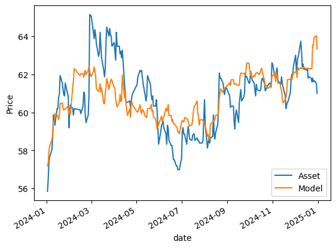

```python
start = '2024-01-01'
end = '2025-01-01'

closes = get_prices('CTG', 'VCB', 'VNINDEX', start_date=start, end_date=end).dropna()

b1 = closes["VNINDEX"]
b2 = closes["CTG"]
a = closes['VCB']

# Run multiple linear regression
mlr = regression.linear_model.OLS(a, sm.add_constant(np.column_stack((b1,b2)))).fit()

# Construct fit curve using dependent variables and estimated coefficients
mlr_prediction = mlr.params.iloc[0] + mlr.params.iloc[1]*b1 + mlr.params.iloc[2]*b2

# Print regression statistics
print('R-squared:', mlr.rsquared_adj)
print('t-statistics of coefficients:\n', mlr.tvalues)

# Plot asset and model
a.plot()
mlr_prediction.plot()
plt.legend(['Asset', 'Model']);
plt.ylabel('Price')
```

```
R-squared: 0.06056722298477868
t-statistics of coefficients:
 const      12.092253
VNINDEX     4.121782
dtype: float64
```

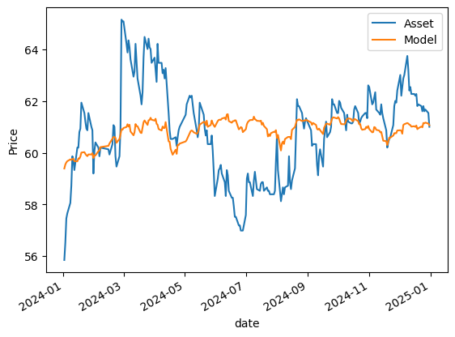

```python
# Perform linear regression
slr = regression.linear_model.OLS(a, sm.add_constant(b1)).fit()
slr_prediction = slr.params.iloc[0] + slr.params.iloc[1]*b1

# Print fit statistics
print('R-squared:', slr.rsquared_adj)
print('t-statistics of coefficients:\n', slr.tvalues)

# Plot asset and model
a.plot()
slr_prediction.plot()
plt.ylabel('Price')
plt.legend(['Asset', 'Model']);
```

## Ví dụ: Bộ tứ Anscombe

Anscombe đã xây dựng 4 bộ dữ liệu không chỉ có cùng trung bình và phương sai ở mỗi biến, mà còn có cùng hệ số tương quan, đường hồi quy và giá trị R-bình phương của hồi quy. Dưới đây, chúng ta sẽ kiểm tra kết quả này cũng như vẽ đồ thị của các bộ dữ liệu. Một cái nhìn nhanh vào các đồ thị cho thấy chỉ bộ dữ liệu đầu tiên đáp ứng các giả định của mô hình hồi quy. Do đó, các giá trị R-bình phương cao của ba bộ dữ liệu còn lại là không có ý nghĩa, điều này phù hợp với trực giác của chúng ta rằng ba bộ dữ liệu còn lại không được mô hình hóa tốt bởi các đường hồi quy tốt nhất.

```
Cofficients: [3.00009091 0.50009091] [3.00090909 0.5       ] [3.00245455 0.49972727] [3.00172727 0.49990909]
Pearson r: 0.8164205163448396 0.8162365060002426 0.816286739489598 0.8165214368885026
R-squared: 0.666542459508775 0.6662420337274844 0.6663240410665593 0.6667072568984652
```

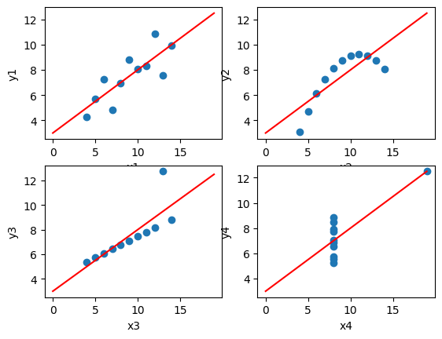

```python
from scipy.stats import pearsonr

# Construct Anscombe's arrays
x1 = [10, 8, 13, 9, 11, 14, 6, 4, 12, 7, 5]
y1 = [8.04, 6.95, 7.58, 8.81, 8.33, 9.96, 7.24, 4.26, 10.84, 4.82, 5.68]
x2 = [10, 8, 13, 9, 11, 14, 6, 4, 12, 7, 5]
y2 = [9.14, 8.14, 8.74, 8.77, 9.26, 8.10, 6.13, 3.10, 9.13, 7.26, 4.74]
x3 = [10, 8, 13, 9, 11, 14, 6, 4, 12, 7, 5]
y3 = [7.46, 6.77, 12.74, 7.11, 7.81, 8.84, 6.08, 5.39, 8.15, 6.42, 5.73]
x4 = [8, 8, 8, 8, 8, 8, 8, 19, 8, 8, 8]
y4 = [6.58, 5.76, 7.71, 8.84, 8.47, 7.04, 5.25, 12.50, 5.56, 7.91, 6.89]

# Perform linear regressions on the datasets
slr1 = regression.linear_model.OLS(y1, sm.add_constant(x1)).fit()
slr2 = regression.linear_model.OLS(y2, sm.add_constant(x2)).fit()
slr3 = regression.linear_model.OLS(y3, sm.add_constant(x3)).fit()
slr4 = regression.linear_model.OLS(y4, sm.add_constant(x4)).fit()

# Print regression coefficients, Pearson r, and R-squared for the 4 datasets
print('Cofficients:', slr1.params, slr2.params, slr3.params, slr4.params)
print('Pearson r:', pearsonr(x1, y1)[0], pearsonr(x2, y2)[0], pearsonr(x3, y3)[0], pearsonr(x4, y4)[0])
print('R-squared:', slr1.rsquared, slr2.rsquared, slr3.rsquared, slr4.rsquared)

# Plot the 4 datasets with their regression lines
f, ((ax1, ax2), (ax3, ax4)) = plt.subplots(2,2)
xs = np.arange(20)
ax1.plot(slr1.params[0] + slr1.params[1]*xs, 'r')
ax1.scatter(x1, y1)
ax1.set_xlabel('x1')
ax1.set_ylabel('y1')
ax2.plot(slr2.params[0] + slr2.params[1]*xs, 'r')
ax2.scatter(x2, y2)
ax2.set_xlabel('x2')
ax2.set_ylabel('y2')
ax3.plot(slr3.params[0] + slr3.params[1]*xs, 'r')
ax3.scatter(x3, y3)
ax3.set_xlabel('x3')
ax3.set_ylabel('y3')
ax4.plot(slr4.params[0] + slr4.params[1]*xs, 'r')
ax4.scatter(x4,y4)
ax4.set_xlabel('x4')
ax4.set_ylabel('y4');
```

## Tham khảo

- "Quantitative Investment Analysis", by DeFusco, McLeavey, Pinto, and Runkle

*Lưu ý: Tài liệu này mang tính chất chia sẻ kiến thức khoa học dữ liệu. Các mã chứng khoán xuất hiện trong tài liệu chỉ mang tính chất minh hoạ, không khuyến nghị đầu tư. Chúng tôi không chịu trách nhiệm trước mọi rủi ro nào do sử dụng tài liệu này.*